# Challenge 7: Incorporating Multiple Inputs

- Show All Code
- Hide All Code
- View Source

Functions + Fish

Author

Eva Moylan

Published

November 20, 2024

```r
library(tidyverse)
library(here)

fish_data <- read_csv(here("data", "BlackfootFish.csv"))
```

## Condition Index

A frequently used measurement for fish health is a condition index [(Wikipedia article)](https://en.wikipedia.org/wiki/Condition_index_in_fish). The following simple equation can be used to calculate the approximate condition index of a fish:

$$\text{condition index} = \frac{weight}{length^3} \times 100$$

**1. There are specific units required for the calculation of a condition index – length must be in centimeters and weight must be in grams. The weight data for the Blackfoot River fish were collected in grams; the length data were collected in millimeters. Transform the length data to the correct units.**

```r
fish_clean <- fish_data |>
  mutate(length = length/10)
```

**2. Collecting data of this sort can be very messy! Write a function that will replace unlikely `length` and `weight` measurements with `NA`. Your function should accept at least three inputs:**

- **a vector of measurements,**
- **the minimum reasonable value,**
- **the maximum reasonable value.**

**If a value falls outside these bounds, you should replace it with an `NA`.**

**Tip**

If you are struggling with the structure of your function, I would suggest reading the [Mutating Function](https://r4ds.hadley.nz/functions.html#mutate-functions) from R4DS.

```r
cutoffs <- function(x, min, max) {

  if(!is.numeric(x)) {
    stop("Input must be numeric")
  }

  case_when(x < min ~ NA, #If x is less than the minimum or greater than the max..
            x > max ~ NA,
            .default = x) #Else, keep as x
}
```

*Question 2 Reflection: I originally used if_else to create the cutoffs function, however because I am trying to replace ‘x’ with NA if it is less than the minimum or greater than the max, case_when would be the better function to use. In the future, if I am considering using if_else for two conditions at once, I will use case_when, which is the most modern syntax.*

**3. After consulting the [Montana Record Table](https://fwp.mt.gov/fish/anglingData/records) for the four species of trout included in these data, I have conjectured that it is unlikely to have measurements for fish below 5 cm and above 80 cm in length or below 10 g and above 4,000 g in weight. Use your function to modify the `length` and `weight` columns of the `fish` dataset based on my cutoffs.**

```r
#Remove below 5cm and above 80cm
#Remove below 10g and above 4,000g

fish_clean <- fish_clean |>
  mutate(length = cutoffs(length,
                          5,
                          80),
         weight = cutoffs(weight,
                          10,
                          4000))
```

**3. Write a function to calculate the condition index of a fish, given inputs of weight and length.**

**Warning**

Consider whether you will write a function that works with vectors (accepting vectors as inputs) or a function that works with data frames (accepting a dataset and variable names as inputs)!

```r
condition.index <- function(x, y) {

  if(!is.numeric(x)) {
    stop("Input must be numeric")
   }

  if(!is.numeric(y)) {
    stop("Input must be numeric")
  }

  return((x/(y^3))*100)
}
```

*Question 3 Reflection: I originally forgot to specify the required datatype for ‘y’, so I added a stop within the function if the input for ‘y’ is not numeric. I also put my calculation within the return function to make my function formatting cleaner. In the future, I will make sure to double check I’ve included the necessary checks for all of my function inputs!*

**4. Make a thoughtful visualization of how fish conditions have varied over the duration of this study.**

**To be thoughtful…**

… you need to use at least a third variable!

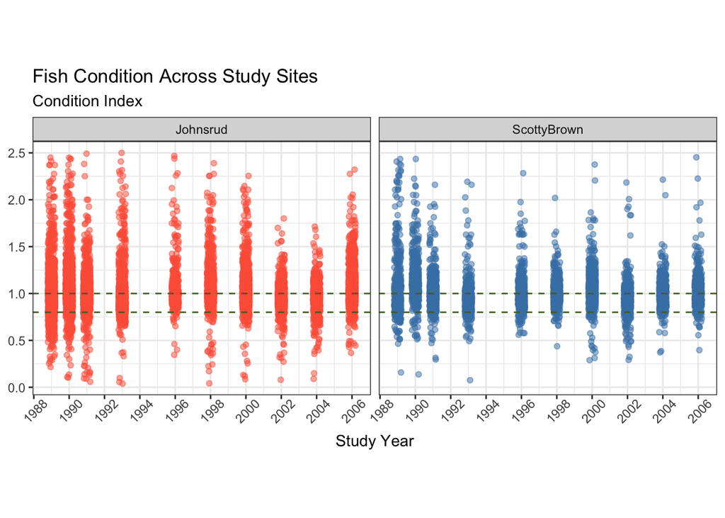

Figure 1. The distribution of trout condition indeces across study years 1988 to 2006 in the Johsrud and Scotty Brown study regions. The green dotted lines represent the healthy index range of 0.8 to 1.

```r
fish_clean |>
  mutate(condition = condition.index(weight,
                                     length)) |>
  filter(condition <= 2.5) |>
  ggplot(mapping = aes(x = year,
                       y = condition,
                       color = section)) +
  geom_jitter(width = 0.2, alpha = 0.5) +
  facet_wrap(~ section) +
  scale_color_manual(values = c("tomato", "steelblue")) +
  scale_x_continuous(n.breaks = 10) +
  theme_bw() +
  geom_hline(yintercept = c(1, 0.8),
             linetype = "dashed",
             color = "darkolivegreen") +
  labs(x = "Study Year",
       y = NULL,
       subtitle = "Condition Index",
       title = "Fish Condition Across Study Sites",
       fill = "Study Section") +
  theme(aspect.ratio = 0.75,
        axis.text.x = element_text(angle = 45,
                                   vjust = 0.75),
        legend.position = "none")
```

*Question 4 Reflection: The healthy condition index range for fish is 0.8 to 1 and the majority of fish in this dataset have a condition index between 0 and 2.5. So, to make the visualization more meaningful I removed outliers with an index above 2.5. I also added dotted lines to the plot to show the healthy index range. In the future, when making plots I will make sure to consider if the data I’m using for a visualization make sense in the context of what the data are representing.*